# Analysis of US Storm Data for Human and Economic Impact

Manu Perez

February 15, 2016

##### Which relation exists between severe weather events and humans? What is the economic impact?

##### This questions and others can be answered by statistic. And, may be in the future, we would can prevent the outcomes to the extent possible.

##### In this paper, we will try to answere there questions. For this, we will use the US Storm data from the NOAA Storm Database.

### Data Processing

##### First, we load the data. You can download the data from https://d396qusza40orc.cloudfront.net/repdata%2Fdata%2FStormData.csv.bz2

```r
cache=TRUE
path <- "D:/Cursos/Coursera/Curso Data Science Specialization 5. Reproducible Research/week 4/"
stormdata <- read.csv(paste(path,"repdata-data-StormData.csv", sep=""))
```

```r
stormdata$YEAR <- as.numeric(format(as.Date(stormdata$BGN_DATE, '%m/%d/%Y'), '%Y'))
stormdata20 <- stormdata[stormdata$YEAR >= 1981,]
```

##### We also clean data that did not have any property damages or crop damage and no fatalities or injuries.

```r
stormdata20 <- stormdata20[(stormdata20$PROPDMG > 0 | stormdata20$CROPDMG > 0 | stormdata20$FATALITIES > 0 | stormdata20$INJURIES > 0),]
```

##### We will aggregate the data by summing up the various Values by Event Type

```r
stormdataAggregated <- aggregate(cbind(stormdata20$PROPDMG, stormdata20$CROPDMG, stormdata20$FATALITIE, stormdata20$INJURIES) ~ stormdata20$EVTYPE, stormdata20, sum)
```

### Results

##### We only visualize the first 5 results.

##### With respect to property damage, TORNADO is the most dangerous weather event.

```r
stormdataPD <- stormdataAggregated[order(-stormdataAggregated[,"V1"]),]
stormdataPD <- stormdataPD[1:5,]
stormdataPD
```

```
##     stormdata20$EVTYPE        V1        V2   V3    V4
## 407            TORNADO 2069037.0 100018.52 2246 36814
## 73         FLASH FLOOD 1420124.6 179200.46  978  1777
## 423          TSTM WIND 1335965.6 109202.60  504  6957
## 86               FLOOD  899938.5 168037.88  470  6789
## 364  THUNDERSTORM WIND  876844.2  66791.45  133  1488
```

##### Plot the data

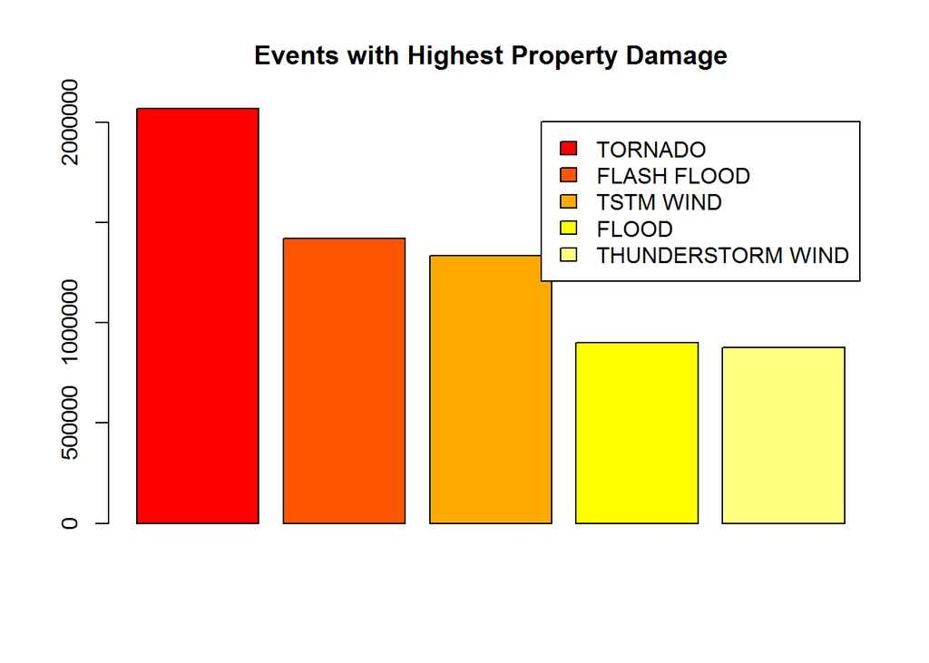

```r
legPD <- as.vector(stormdataPD[,1])
barplot(c(as.numeric(unlist(stormdataPD["V1"]))), legend.text=legPD, main="Events with Highest Property Damage", col=heat.colors(5))
```

##### With respect to crop damage, HAIL is the most dangerous weather event.

```r
stormdataCD <- stormdataAggregated[order(-stormdataAggregated[,"V2"]),]
stormdataCD <- stormdataCD[1:5,]
stormdataCD
```

```
##     stormdata20$EVTYPE        V1       V2   V3    V4
## 134               HAIL  688693.4 579596.3   15  1361
## 73         FLASH FLOOD 1420124.6 179200.5  978  1777
## 86               FLOOD  899938.5 168037.9  470  6789
## 423          TSTM WIND 1335965.6 109202.6  504  6957
## 407            TORNADO 2069037.0 100018.5 2246 36814
```

##### Plot the data

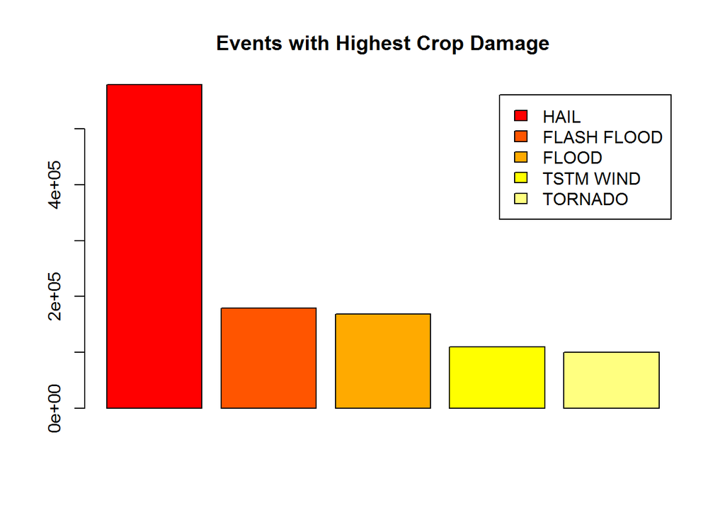

```r
legCD <- as.vector(stormdataCD[,1])
barplot(c(as.numeric(unlist(stormdataCD["V2"]))), legend.text=legCD, main="Events with Highest Crop Damage", col=heat.colors(5))
```

##### With respect to population impact, first, we combine fatalities and injuries.

```r
stormdataAggregated$POPIMP <- stormdataAggregated[,"V3"] + stormdataAggregated[,"V4"]
stormdataPI <- stormdataAggregated[order(-stormdataAggregated$POPIMP),]
stormdataPI <- stormdataPI[1:5,]
stormdataPI
```

```
##     stormdata20$EVTYPE        V1        V2   V3    V4 POPIMP
## 407            TORNADO 2069037.0 100018.52 2246 36814  39060
## 61      EXCESSIVE HEAT    1460.0    494.40 1903  6525   8428
## 423          TSTM WIND 1335965.6 109202.60  504  6957   7461
## 86               FLOOD  899938.5 168037.88  470  6789   7259
## 258          LIGHTNING  603351.8   3580.61  816  5230   6046
```

##### Then, we can see that TORNADO is the most important population impact.

##### Plot the data

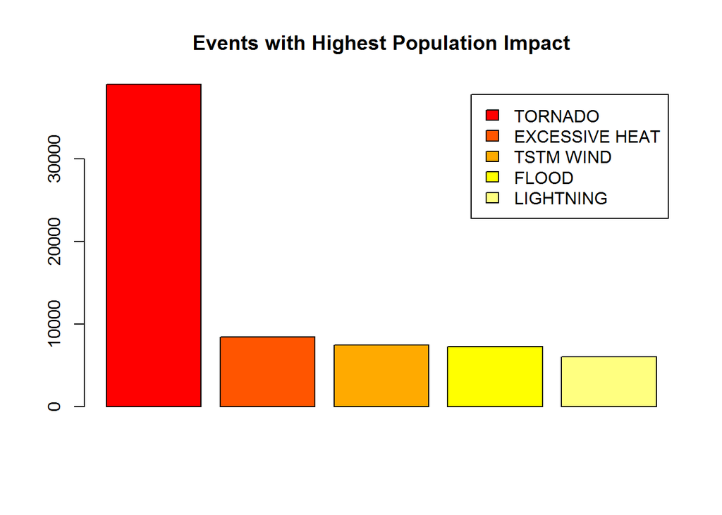

```r
legPI <- as.vector(stormdataPI[,1])
barplot(c(as.numeric(unlist(stormdataPI$POPIMP))), legend.text=legPI, main="Events with Highest Population Impact", col=heat.colors(5))
```